# Contenido

```python
# Ajustamos el tipo de dato de las columnas
df["lead_time"] = df["stays_in_weekend_nights"].astype(int)
df["arrival_date_year"] = df["arrival_date_year"].astype(object)
df["arrival_date_week_number"] = df["arrival_date_week_number"].astype(object)
df["stays_in_weekend_nights"] = df["stays_in_weekend_nights"].astype(int)
df["stays_in_week_nights"] = df["stays_in_week_nights"].astype(int)
df["adults"] = df["adults"].astype(int)
df["children"] = df["children"].astype(int)
df["babies"] = df["babies"].astype(int)
df["previous_cancellations"] = df["previous_cancellations"].astype(int)
df["previous_bookings_not_canceled"] = df["previous_bookings_not_canceled"].astype(int)
df["booking_changes"] = df["booking_changes"].astype(int)
df["days_in_waiting_list"] = df["days_in_waiting_list"].astype(int)
df["adr"] = df["adr"].astype(float)
df["required_car_parking_spaces"] = df["required_car_parking_spaces"].astype(int)
df["total_of_special_requests"] = df["total_of_special_requests"].astype(int)
df.dtypes
```

```
hotel                              object
is_canceled                        object
lead_time                           int32
arrival_date_year                  object
arrival_date_month                 object
arrival_date_week_number           object
arrival_date_day_of_month          object
stays_in_weekend_nights             int32
stays_in_week_nights                int32
adults                              int32
children                            int32
babies                              int32
meal                               object
country                            object
market_segment                     object
distribution_channel               object
is_repeated_guest                  object
previous_cancellations              int32
previous_bookings_not_canceled      int32
reserved_room_type                 object
assigned_room_type                 object
booking_changes                     int32
deposit_type                       object
agent                              object
days_in_waiting_list                int32
customer_type                      object
adr                               float64
required_car_parking_spaces         int32
total_of_special_requests           int32
reservation_status                 object
reservation_status_date            object
dtype: object
```

```python
# Obtenemos un resumen estadístico de las columnas numéricas
df.describe()
```

|  | lead_time | stays_in_weekend_nights | stays_in_week_nights | adults | children | babies | previous_cancellations | previous_bookings_not_canceled | booking_changes | days_in_waiting_list | adr | required_car_parking_spaces | total_of_special_requests |
| --- | --- | --- | --- | --- | --- | --- | --- | --- | --- | --- | --- | --- | --- |
| count | 86944.000000 | 86944.000000 | 86944.000000 | 86944.000000 | 86944.000000 | 86944.000000 | 86944.000000 | 86944.000000 | 86944.000000 | 86944.000000 | 86944.000000 | 86944.000000 | 86944.000000 |
| mean | 1.007384 | 1.007384 | 2.628727 | 1.878543 | 0.139205 | 0.010835 | 0.030226 | 0.176700 | 0.271842 | 0.753462 | 106.571263 | 0.083445 | 0.699485 |
| std | 1.028757 | 1.028757 | 2.043744 | 0.625858 | 0.456777 | 0.113590 | 0.369566 | 1.717846 | 0.728076 | 10.041586 | 54.958962 | 0.280396 | 0.831835 |
| min | 0.000000 | 0.000000 | 0.000000 | 0.000000 | 0.000000 | 0.000000 | 0.000000 | 0.000000 | 0.000000 | 0.000000 | -6.380000 | 0.000000 | 0.000000 |
| 25% | 0.000000 | 0.000000 | 1.000000 | 2.000000 | 0.000000 | 0.000000 | 0.000000 | 0.000000 | 0.000000 | 0.000000 | 72.250000 | 0.000000 | 0.000000 |
| 50% | 1.000000 | 1.000000 | 2.000000 | 2.000000 | 0.000000 | 0.000000 | 0.000000 | 0.000000 | 0.000000 | 0.000000 | 98.400000 | 0.000000 | 0.000000 |
| 75% | 2.000000 | 2.000000 | 4.000000 | 2.000000 | 0.000000 | 0.000000 | 0.000000 | 0.000000 | 0.000000 | 0.000000 | 134.100000 | 0.000000 | 1.000000 |
| max | 16.000000 | 16.000000 | 41.000000 | 55.000000 | 10.000000 | 10.000000 | 26.000000 | 72.000000 | 21.000000 | 391.000000 | 5400.000000 | 8.000000 | 5.000000 |

```python
# Removemos outliers
df_numeric = df._get_numeric_data()
z_scores = stats.zscore(df_numeric)
abs_z_scores = np.abs(z_scores)
filtered_entries = (abs_z_scores < 3).all(axis=1)
df = df[filtered_entries]
df
```

|  | hotel | is_canceled | lead_time | arrival_date_year | arrival_date_month | arrival_date_week_number | arrival_date_day_of_month | stays_in_weekend_nights | stays_in_week_nights | adults | children | babies | meal | country | market_segment | distribution_channel | is_repeated_guest | previous_cancellations | previous_bookings_not_canceled | reserved_room_type | assigned_room_type | booking_changes | deposit_type | agent | days_in_waiting_list | customer_type | adr | required_car_parking_spaces | total_of_special_requests | … |
| --- | --- | --- | --- | --- | --- | --- | --- | --- | --- | --- | --- | --- | --- | --- | --- | --- | --- | --- | --- | --- | --- | --- | --- | --- | --- | --- | --- | --- | --- | --- |
| 0 | City Hotel | 1 | 0 | 2017 | March | 11 | 16 | 0 | 2 | 2 | 0 | 0 | BB | PRT | Groups | TA/TO | 0 | 0 | 0 | A | A | 0 | Non Refund | 1 | 0 | Transient | 62.00 | 0 | 0 | … |
| 11 | City Hotel | 1 | 0 | 2017 | March | 11 | 16 | 0 | 3 | 2 | 0 | 0 | BB | NLD | Online TA | TA/TO | 0 | 0 | 0 | D | D | 0 | No Deposit | 9 | 0 | Transient | 128.00 | 0 | 0 | … |
| 13 | City Hotel | 1 | 0 | 2017 | March | 11 | 16 | 0 | 3 | 2 | 0 | 0 | SC | FRA | Online TA | TA/TO | 0 | 0 | 0 | A | A | 0 | No Deposit | 9 | 0 | Transient | 79.20 | 0 | 1 | … |
| 14 | City Hotel | 1 | 0 | 2017 | March | 11 | 16 | 0 | 3 | 3 | 0 | 0 | BB | IRL | Online TA | TA/TO | 0 | 0 | 0 | D | D | 0 | No Deposit | 9 | 0 | Transient | 122.40 | 0 | 0 | … |
| 15 | City Hotel | 1 | 0 | 2017 | March | 11 | 16 | 0 | 3 | 2 | 0 | 0 | BB | PRT | Online TA | TA/TO | 0 | 0 | 0 | A | A | 0 | No Deposit | 9 | 0 | Transient | 118.00 | 0 | 0 | … |
| ... | ... | ... | ... | ... | ... | ... | ... | ... | ... | ... | ... | ... | ... | ... | ... | ... | ... | ... | ... | ... | ... | ... | ... | ... | ... | ... | ... | ... | ... | … |
| 119384 | City Hotel | 1 | 2 | 2016 | July | 29 | 14 | 2 | 5 | 2 | 0 | 0 | SC | GBR | Online TA | TA/TO | 0 | 0 | 0 | A | A | 0 | No Deposit | 9 | 0 | Transient | 86.82 | 0 | 0 | … |
| 119385 | City Hotel | 1 | 2 | 2016 | July | 29 | 14 | 2 | 8 | 3 | 0 | 0 | BB | FRA | Online TA | TA/TO | 0 | 0 | 0 | D | D | 0 | No Deposit | 9 | 0 | Transient | 131.75 | 0 | 2 | … |
| 119386 | City Hotel | 1 | 2 | 2016 | July | 29 | 14 | 2 | 8 | 2 | 0 | 0 | BB | FRA | Online TA | TA/TO | 0 | 0 | 0 | A | A | 0 | No Deposit | 9 | 0 | Transient | 101.15 | 0 | 1 | … |
| 119387 | City Hotel | 1 | 0 | 2016 | July | 29 | 15 | 0 | 1 | 3 | 0 | 0 | BB | PRT | Online TA | TA/TO | 0 | 0 | 0 | D | D | 0 | No Deposit | 9 | 0 | Transient | 137.70 | 0 | 1 | … |
| 119388 | City Hotel | 1 | 0 | 2016 | July | 29 | 15 | 0 | 1 | 3 | 0 | 0 | BB | FRA | Online TA | TA/TO | 0 | 0 | 0 | D | D | 0 | No Deposit | 9 | 0 | Transient | 197.00 | 0 | 1 | … |

71324 rows × 31 columns

```python
# Obtenemos nuevamente un resumen estadístico de las columnas numéricas
df.describe()
```

|  | lead_time | stays_in_weekend_nights | stays_in_week_nights | adults | children | babies | previous_cancellations | previous_bookings_not_canceled | booking_changes | days_in_waiting_list | adr | required_car_parking_spaces | total_of_special_requests |
| --- | --- | --- | --- | --- | --- | --- | --- | --- | --- | --- | --- | --- | --- |
| count | 71324.000000 | 71324.000000 | 71324.000000 | 71324.000000 | 71324.000000 | 71324.0 | 71324.000000 | 71324.000000 | 71324.000000 | 71324.000000 | 71324.000000 | 71324.0 | 71324.000000 |
| mean | 0.958780 | 0.958780 | 2.481451 | 1.881611 | 0.052423 | 0.0 | 0.015086 | 0.050670 | 0.191352 | 0.038472 | 102.782714 | 0.0 | 0.669256 |
| std | 0.914091 | 0.914091 | 1.636509 | 0.498618 | 0.222880 | 0.0 | 0.121896 | 0.367696 | 0.478707 | 0.873330 | 45.785484 | 0.0 | 0.792632 |
| min | 0.000000 | 0.000000 | 0.000000 | 1.000000 | 0.000000 | 0.0 | 0.000000 | 0.000000 | 0.000000 | 0.000000 | -6.380000 | 0.0 | 0.000000 |
| 25% | 0.000000 | 0.000000 | 1.000000 | 2.000000 | 0.000000 | 0.0 | 0.000000 | 0.000000 | 0.000000 | 0.000000 | 73.000000 | 0.0 | 0.000000 |
| 50% | 1.000000 | 1.000000 | 2.000000 | 2.000000 | 0.000000 | 0.0 | 0.000000 | 0.000000 | 0.000000 | 0.000000 | 97.200000 | 0.0 | 0.000000 |
| 75% | 2.000000 | 2.000000 | 3.000000 | 2.000000 | 0.000000 | 0.0 | 0.000000 | 0.000000 | 0.000000 | 0.000000 | 129.000000 | 0.0 | 1.000000 |
| max | 4.000000 | 4.000000 | 8.000000 | 3.000000 | 1.000000 | 0.0 | 1.000000 | 5.000000 | 2.000000 | 30.000000 | 271.000000 | 0.0 | 3.000000 |

```python
# Exportamos el dataset después de haber realizado la limpieza correspondiente
df.to_csv("Data_Limpia.csv")
```

## PREGUNTAS

### 1. ¿De dónde vienen los huéspedes?

* Asumiremos de donde vienen los huespedes que realizan la reservación, independientemente de si la cancelaron o no.

```python
# Establecimos algunas configuraciones para las gráficas
%matplotlib inline
mpl.style.use('ggplot')
```

```python
# Agrupamos por país y mostramos el top ten
df_country = df.groupby('country', axis=0).agg('count')
df_country = df_country[['hotel']].rename(columns={'hotel': 'value_counts'})
df_country['percentage'] = round((df_country['value_counts']/df_country['value_counts'].sum()) * 100, 3)
df_country_ord = df_country.sort_values('value_counts', ascending = False).head(10)
df_country_ord
```

| country | value_counts | percentage |
| --- | --- | --- |
| PRT | 21412 | 30.021 |
| GBR | 8752 | 12.271 |
| FRA | 7598 | 10.653 |
| ESP | 5444 | 7.633 |
| DEU | 4824 | 6.764 |
| ITA | 2684 | 3.763 |
| IRL | 2675 | 3.750 |
| BEL | 1792 | 2.512 |
| BRA | 1673 | 2.346 |
| NLD | 1578 | 2.212 |

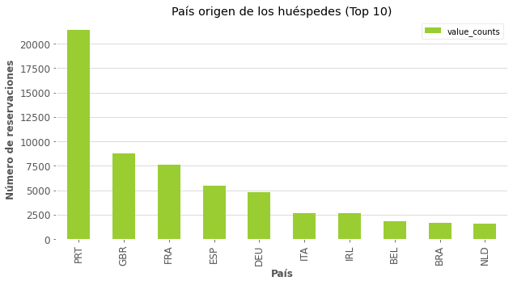

```python
# Graficamos el top ten
df_country_ord[['value_counts']].plot(kind='bar', figsize=(10,5), color='yellowgreen', fontsize=12)
plt.grid(visible = True, color = 'lightgray', axis = 'y')
plt.title('País origen de los huéspedes (Top 10)')
plt.ylabel('Número de reservaciones',fontweight='bold')
plt.xlabel('País',fontweight='bold')
plt.rcParams['axes.facecolor'] = 'white'
plt.show()
```

##### R = Los huéspedes provienen al menos de 172 países diferentes. Aproximadamente el 30% son de Portugal.

### 6. Reservas por segmento de mercado

```python
# Contamos los registros agrupados por segmento de mercado
df_segmento = df.groupby('market_segment', axis=0).agg('count')
df_segmento = df_segmento[['hotel']].rename(columns={'hotel': 'value_counts'})
df_segmento['percentage'] = round((df_segmento['value_counts']/df_segmento['value_counts'].sum()) * 100, 3)
df_segmento = df_segmento.sort_values('value_counts', ascending = False)
df_segmento
```

| market_segment | value_counts | percentage |
| --- | --- | --- |
| Online TA | 43314 | 60.729 |
| Offline TA/TO | 11936 | 16.735 |
| Direct | 8386 | 11.758 |
| Groups | 4076 | 5.715 |
| Corporate | 2947 | 4.132 |
| Complementary | 468 | 0.656 |
| Aviation | 195 | 0.273 |
| Undefined | 2 | 0.003 |

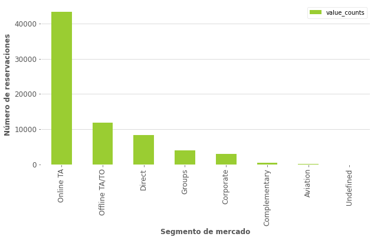

```python
# Graficamos
df_segmento[['value_counts']].plot(kind='bar', figsize=(10,5), color = 'yellowgreen', fontsize=12)
plt.grid(visible = True, color = 'lightgray', axis = 'y')
#plt.title('Reservaciones por segmento de mercado')
plt.ylabel('Número de reservaciones',fontweight='bold')
plt.xlabel('Segmento de mercado',fontweight='bold')
plt.show()
```

### 7. ¿Cuántas reservas se cancelaron?

```python
# Visualizamos los registros correspondientes a reservaciones canceladas
df_canceled = df[df['is_canceled'] == '1']
df_canceled
```

|  | hotel | is_canceled | lead_time | arrival_date_year | arrival_date_month | arrival_date_week_number | arrival_date_day_of_month | stays_in_weekend_nights | stays_in_week_nights | adults | children | babies | meal | country | market_segment | distribution_channel | is_repeated_guest | previous_cancellations | previous_bookings_not_canceled | reserved_room_type | assigned_room_type | booking_changes | deposit_type | agent | days_in_waiting_list | customer_type | adr | required_car_parking_spaces | total_of_special_requests | … |
| --- | --- | --- | --- | --- | --- | --- | --- | --- | --- | --- | --- | --- | --- | --- | --- | --- | --- | --- | --- | --- | --- | --- | --- | --- | --- | --- | --- | --- | --- | --- |
| 0 | City Hotel | 1 | 0 | 2017 | March | 11 | 16 | 0 | 2 | 2 | 0 | 0 | BB | PRT | Groups | TA/TO | 0 | 0 | 0 | A | A | 0 | Non Refund | 1 | 0 | Transient | 62.00 | 0 | 0 | … |
| 11 | City Hotel | 1 | 0 | 2017 | March | 11 | 16 | 0 | 3 | 2 | 0 | 0 | BB | NLD | Online TA | TA/TO | 0 | 0 | 0 | D | D | 0 | No Deposit | 9 | 0 | Transient | 128.00 | 0 | 0 | … |
| 13 | City Hotel | 1 | 0 | 2017 | March | 11 | 16 | 0 | 3 | 2 | 0 | 0 | SC | FRA | Online TA | TA/TO | 0 | 0 | 0 | A | A | 0 | No Deposit | 9 | 0 | Transient | 79.20 | 0 | 1 | … |
| 14 | City Hotel | 1 | 0 | 2017 | March | 11 | 16 | 0 | 3 | 3 | 0 | 0 | BB | IRL | Online TA | TA/TO | 0 | 0 | 0 | D | D | 0 | No Deposit | 9 | 0 | Transient | 122.40 | 0 | 0 | … |
| 15 | City Hotel | 1 | 0 | 2017 | March | 11 | 16 | 0 | 3 | 2 | 0 | 0 | BB | PRT | Online TA | TA/TO | 0 | 0 | 0 | A | A | 0 | No Deposit | 9 | 0 | Transient | 118.00 | 0 | 0 | … |
| ... | ... | ... | ... | ... | ... | ... | ... | ... | ... | ... | ... | ... | ... | ... | ... | ... | ... | ... | ... | ... | ... | ... | ... | ... | ... | ... | ... | ... | ... | … |
| 119384 | City Hotel | 1 | 2 | 2016 | July | 29 | 14 | 2 | 5 | 2 | 0 | 0 | SC | GBR | Online TA | TA/TO | 0 | 0 | 0 | A | A | 0 | No Deposit | 9 | 0 | Transient | 86.82 | 0 | 0 | … |
| 119385 | City Hotel | 1 | 2 | 2016 | July | 29 | 14 | 2 | 8 | 3 | 0 | 0 | BB | FRA | Online TA | TA/TO | 0 | 0 | 0 | D | D | 0 | No Deposit | 9 | 0 | Transient | 131.75 | 0 | 2 | … |
| 119386 | City Hotel | 1 | 2 | 2016 | July | 29 | 14 | 2 | 8 | 2 | 0 | 0 | BB | FRA | Online TA | TA/TO | 0 | 0 | 0 | A | A | 0 | No Deposit | 9 | 0 | Transient | 101.15 | 0 | 1 | … |
| 119387 | City Hotel | 1 | 0 | 2016 | July | 29 | 15 | 0 | 1 | 3 | 0 | 0 | BB | PRT | Online TA | TA/TO | 0 | 0 | 0 | D | D | 0 | No Deposit | 9 | 0 | Transient | 137.70 | 0 | 1 | … |
| 119388 | City Hotel | 1 | 0 | 2016 | July | 29 | 15 | 0 | 1 | 3 | 0 | 0 | BB | FRA | Online TA | TA/TO | 0 | 0 | 0 | D | D | 0 | No Deposit | 9 | 0 | Transient | 197.00 | 0 | 1 | … |

21165 rows × 31 columns

```python
# Contamos los registros correspondientes a reservaciones canceladas y no canceladas
df_cancel = df.groupby('is_canceled', axis=0).agg('count')
df_cancel = df_cancel[['hotel']].rename(columns={'hotel': 'value_counts'},index = {'0':'No Canceladas','1':'Canceladas'})
df_cancel['percentage'] = round((df_cancel['value_counts']/df_cancel['value_counts'].sum()) * 100, 2)
df_cancel
```

| is_canceled | value_counts | percentage |
| --- | --- | --- |
| No Canceladas | 50159 | 70.33 |
| Canceladas | 21165 | 29.67 |

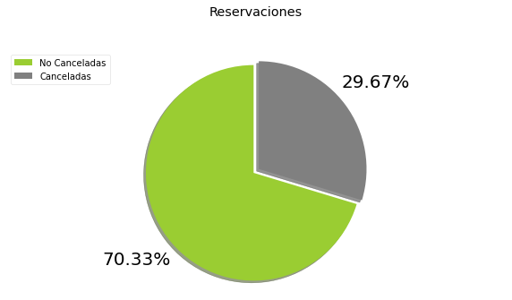

```python
# Graficamos
df_cancel['value_counts'].plot(kind = 'pie',
                            figsize = (10, 5),
                            fontsize = 20,
                            autopct = '%1.2f%%',
                            startangle = 90,
                            shadow = True,
                            labels = None,
                            pctdistance = 1.35,
                            colors = ['yellowgreen','gray'],
                            explode = [0.03, 0.03]
                            )

plt.title('Reservaciones', y=1.12)
plt.legend(labels=df_cancel.index, loc='upper left')
plt.axis('equal')
plt.ylabel(None)
plt.show()
```

### 8. ¿Qué mes tiene el mayor número de cancelaciones?

```python
# Agrupamos las reservaciones canceladas por el mes de la fecha de arribo
df_canceled_mes = df_canceled.groupby('arrival_date_month', axis=0).agg('count')
df_canceled_mes = df_canceled_mes[['hotel']].rename(columns={'hotel': 'value_counts'})
df_canceled_mes['percentage'] = round((df_canceled_mes['value_counts']/df_canceled_mes['value_counts'].sum()) * 100, 2)
df_canceled_mes = df_canceled_mes.sort_values('value_counts', ascending = False)
df_canceled_mes
```

| arrival_date_month | value_counts | percentage |
| --- | --- | --- |
| August | 3100 | 14.65 |
| July | 2773 | 13.10 |
| May | 2182 | 10.31 |
| April | 2131 | 10.07 |
| June | 2069 | 9.78 |
| March | 1649 | 7.79 |
| October | 1483 | 7.01 |
| September | 1444 | 6.82 |
| February | 1268 | 5.99 |
| December | 1201 | 5.67 |
| November | 968 | 4.57 |
| January | 897 | 4.24 |

```python
# Ordenamos por mes
df_canceled_mes_orden = pd.DataFrame(df_canceled_mes.loc[['January','February','March','April','May','June','July','August',
                                               'September','October','November','December'],['value_counts','percentage']])
df_canceled_mes_orden
```

| arrival_date_month | value_counts | percentage |
| --- | --- | --- |
| January | 897 | 4.24 |
| February | 1268 | 5.99 |
| March | 1649 | 7.79 |
| April | 2131 | 10.07 |
| May | 2182 | 10.31 |
| June | 2069 | 9.78 |
| July | 2773 | 13.10 |
| August | 3100 | 14.65 |
| September | 1444 | 6.82 |
| October | 1483 | 7.01 |
| November | 968 | 4.57 |
| December | 1201 | 5.67 |

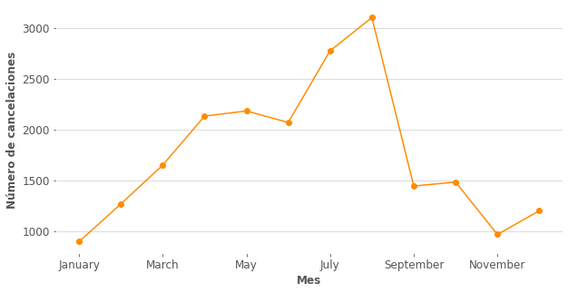

```python
# Graficamos
df_canceled_mes_orden['value_counts'].plot(kind='line', figsize = (10, 5), color='darkorange', marker='o', fontsize = 12)
plt.grid(visible = True, color = 'lightgray', axis = 'y')
#plt.title('Cancelaciones por mes')
plt.ylabel('Número de cancelaciones',fontweight='bold')
plt.xlabel('Mes',fontweight='bold')
plt.show()
```

### 4. ¿Cuáles son los meses más ocupados?

```python
# Visualizamos los registros correspondientes a reservaciones no canceladas
df_not_canceled = df[df['is_canceled'] == '0']
df_not_canceled
```

|  | hotel | is_canceled | lead_time | arrival_date_year | arrival_date_month | arrival_date_week_number | arrival_date_day_of_month | stays_in_weekend_nights | stays_in_week_nights | adults | children | babies | meal | country | market_segment | distribution_channel | is_repeated_guest | previous_cancellations | previous_bookings_not_canceled | reserved_room_type | assigned_room_type | booking_changes | deposit_type | agent | days_in_waiting_list | customer_type | adr | required_car_parking_spaces | total_of_special_requests | … |
| --- | --- | --- | --- | --- | --- | --- | --- | --- | --- | --- | --- | --- | --- | --- | --- | --- | --- | --- | --- | --- | --- | --- | --- | --- | --- | --- | --- | --- | --- | --- |
| 326 | City Hotel | 0 | 3 | 2016 | July | 30 | 23 | 3 | 6 | 2 | 1 | 0 | BB | DEU | Online TA | TA/TO | 0 | 0 | 0 | D | D | 0 | No Deposit | 7 | 0 | Transient | 94.51 | 0 | 2 | … |
| 343 | City Hotel | 0 | 2 | 2016 | July | 31 | 24 | 2 | 2 | 2 | 0 | 0 | BB | BEL | Online TA | TA/TO | 0 | 0 | 0 | A | A | 0 | No Deposit | 9 | 0 | Transient | 90.95 | 0 | 0 | … |
| 352 | City Hotel | 0 | 1 | 2016 | July | 31 | 25 | 1 | 0 | 2 | 0 | 0 | BB | FRA | Online TA | TA/TO | 0 | 0 | 0 | A | A | 0 | No Deposit | 9 | 0 | Transient | 96.30 | 0 | 2 | … |
| 380 | City Hotel | 0 | 1 | 2016 | July | 31 | 25 | 1 | 4 | 2 | 0 | 0 | BB | DEU | Online TA | TA/TO | 0 | 0 | 0 | A | A | 0 | No Deposit | 9 | 0 | Transient | 90.95 | 0 | 0 | … |
| 383 | City Hotel | 0 | 1 | 2016 | July | 31 | 25 | 1 | 4 | 2 | 0 | 0 | BB | SVN | Direct | Direct | 0 | 0 | 0 | A | A | 0 | No Deposit | 14 | 0 | Transient | 80.75 | 0 | 0 | … |
| ... | ... | ... | ... | ... | ... | ... | ... | ... | ... | ... | ... | ... | ... | ... | ... | ... | ... | ... | ... | ... | ... | ... | ... | ... | ... | ... | ... | ... | ... | … |
| 119307 | City Hotel | 0 | 0 | 2016 | July | 29 | 12 | 0 | 1 | 1 | 0 | 0 | BB | PRT | Online TA | TA/TO | 0 | 0 | 0 | B | A | 0 | No Deposit | 9 | 0 | Transient | 0.00 | 0 | 0 | … |
| 119314 | City Hotel | 0 | 0 | 2016 | July | 29 | 12 | 0 | 4 | 2 | 0 | 0 | BB | NLD | Online TA | TA/TO | 0 | 0 | 0 | B | B | 1 | No Deposit | 9 | 0 | Transient-Party | 81.81 | 0 | 0 | … |
| 119316 | City Hotel | 0 | 0 | 2016 | July | 29 | 12 | 0 | 4 | 2 | 0 | 0 | BB | PRT | Online TA | TA/TO | 0 | 0 | 0 | B | B | 0 | No Deposit | 9 | 0 | Transient-Party | 81.82 | 0 | 0 | … |
| 119317 | City Hotel | 0 | 0 | 2016 | July | 29 | 12 | 0 | 4 | 2 | 0 | 0 | BB | FRA | Online TA | TA/TO | 0 | 0 | 0 | B | B | 0 | No Deposit | 9 | 0 | Transient-Party | 81.50 | 0 | 1 | … |
| 119344 | City Hotel | 0 | 2 | 2016 | July | 29 | 13 | 2 | 7 | 2 | 0 | 0 | BB | DEU | Online TA | TA/TO | 0 | 0 | 0 | A | A | 0 | No Deposit | 9 | 0 | Transient | 90.95 | 0 | 0 | … |

50159 rows × 31 columns

```python
# Agrupamos las reservaciones NO canceladas por el mes de la fecha de arribo
df_not_canceled_mes = df_not_canceled.groupby('arrival_date_month', axis=0).agg('count')
df_not_canceled_mes = df_not_canceled_mes[['hotel']].rename(columns={'hotel': 'value_counts'})
df_not_canceled_mes['percentage'] = round((df_not_canceled_mes['value_counts']/df_not_canceled_mes['value_counts'].sum()) * 100, 2)
df_not_canceled_mes = df_not_canceled_mes.sort_values('value_counts', ascending = False)
df_not_canceled_mes
```

| arrival_date_month | value_counts | percentage |
| --- | --- | --- |
| August | 5737 | 11.44 |
| July | 5223 | 10.41 |
| May | 4841 | 9.65 |
| March | 4712 | 9.39 |
| April | 4382 | 8.74 |
| June | 4294 | 8.56 |
| October | 4255 | 8.48 |
| September | 4057 | 8.09 |
| February | 3783 | 7.54 |
| November | 3193 | 6.37 |
| December | 2862 | 5.71 |
| January | 2820 | 5.62 |

```python
# Ordenamos cronológicamente por mes
df_not_canceled_mes_orden = pd.DataFrame(df_not_canceled_mes.loc[['January','February','March','April','May','June','July','August',
                                               'September','October','November','December'],['value_counts','percentage']])
df_not_canceled_mes_orden
```

| arrival_date_month | value_counts | percentage |
| --- | --- | --- |
| January | 2820 | 5.62 |
| February | 3783 | 7.54 |
| March | 4712 | 9.39 |
| April | 4382 | 8.74 |
| May | 4841 | 9.65 |
| June | 4294 | 8.56 |
| July | 5223 | 10.41 |
| August | 5737 | 11.44 |
| September | 4057 | 8.09 |
| October | 4255 | 8.48 |
| November | 3193 | 6.37 |
| December | 2862 | 5.71 |

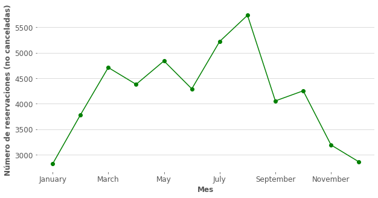

```python
# Graficamos
df_not_canceled_mes_orden['value_counts'].plot(kind='line',figsize = (10, 5),color='green', marker='o', fontsize=12)
plt.grid(visible = True, color = 'lightgray', axis = 'y')
#plt.title('Ocupación por mes')
plt.ylabel('Número de reservaciones (no canceladas)',fontweight='bold')
plt.xlabel('Mes',fontweight='bold')
plt.show()
```

##### R = El mes con la mayor ocupación es Agosto, con al menos 5737 reservaciones no canceladas, correspondiente aproximadamente al 11.5 % del total de las reservaciones no canceladas.

### 5. ¿Cuánto tiempo se queda la gente en los hoteles?

Se considerará el tiempo que se hospedó la gente que no canceló la reservación.

```python
# Contamos el número de noches de las reservaciones no canceladas
df_tiempo = df_not_canceled[['stays_in_weekend_nights','stays_in_week_nights']].reset_index()
df_tiempo = df_tiempo.drop(['index'],axis=1)
df_tiempo['stays_nights_total'] = df_tiempo.sum(axis=1)
df_tiempo_ord = df_tiempo.sort_values('stays_nights_total',ascending=False).head(10)
df_tiempo_ord
```

|  | stays_in_weekend_nights | stays_in_week_nights | stays_nights_total |
| --- | --- | --- | --- |
| 352 | 4 | 8 | 12 |
| 37402 | 4 | 8 | 12 |
| 7937 | 4 | 8 | 12 |
| 20061 | 4 | 8 | 12 |
| 24602 | 4 | 8 | 12 |
| 20215 | 4 | 8 | 12 |
| 20595 | 4 | 8 | 12 |
| 30643 | 4 | 8 | 12 |
| 42100 | 4 | 8 | 12 |
| 43561 | 4 | 8 | 12 |

```python
# Promedio de noches de hospedaje reservadas
round(df_tiempo['stays_nights_total'].sum()/len(df_tiempo.index),1)
```

```
3.3
```

```python
# Agrupamos por el número de noches reservadas
df_tiempo_group = df_tiempo.groupby('stays_nights_total', axis=0).agg('count')
df_tiempo_group = df_tiempo_group[['stays_in_weekend_nights']].rename(columns={'stays_in_weekend_nights': 'value_counts'})
df_tiempo_group['percentage'] = round((df_tiempo_group['value_counts']/df_tiempo_group['value_counts'].sum()) * 100, 3)
df_tiempo_group = df_tiempo_group.sort_values('value_counts', ascending = False)
df_tiempo_group.head(10)
```

| stays_nights_total | value_counts | percentage |
| --- | --- | --- |
| 1 | 10868 | 21.667 |
| 3 | 10284 | 20.503 |
| 2 | 9022 | 17.987 |
| 4 | 7959 | 15.868 |
| 7 | 4318 | 8.609 |
| 5 | 3791 | 7.558 |
| 6 | 1625 | 3.240 |
| 10 | 631 | 1.258 |
| 0 | 514 | 1.025 |
| 8 | 503 | 1.003 |

```python
# Ordenamos por número de noche
df_tiempo_group_orden = pd.DataFrame(df_tiempo_group.loc[[1,2,3,4,5,6,7,8,9,10,11,12],['value_counts','percentage']])
df_tiempo_group_orden
```

| stays_nights_total | value_counts | percentage |
| --- | --- | --- |
| 1 | 10868 | 21.667 |
| 2 | 9022 | 17.987 |
| 3 | 10284 | 20.503 |
| 4 | 7959 | 15.868 |
| 5 | 3791 | 7.558 |
| 6 | 1625 | 3.240 |
| 7 | 4318 | 8.609 |
| 8 | 503 | 1.003 |
| 9 | 415 | 0.827 |
| 10 | 631 | 1.258 |
| 11 | 169 | 0.337 |
| 12 | 60 | 0.120 |

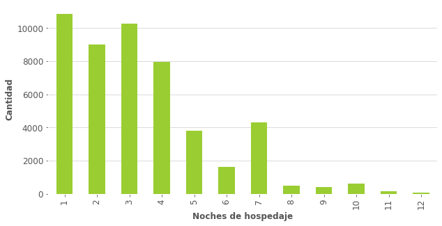

```python
# Graficamos
df_tiempo_group_orden['value_counts'].plot(kind='bar',figsize=(10,5), color = 'yellowgreen', fontsize=12)
plt.grid(visible = True, color = 'lightgray', axis = 'y')
#plt.title('Noches de hospedaje')
plt.ylabel('Cantidad',fontweight='bold')
plt.xlabel('Noches de hospedaje',fontweight='bold')
plt.show()
```

##### R = En promedio, la gente se hospeda aproximadamente 3.3 días, siendo lo más frecuente entre 1 y 4 noches.

### 3. ¿Cómo varía el precio por noche durante el año?

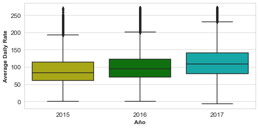

```python
my_pal = {2015: "y", 2016: "g", 2017:"c"}
sns.set_style("whitegrid")
sns.boxplot(x="arrival_date_year", y="adr", data=df, palette=my_pal)
plt.rcParams['figure.figsize'] = 8.5,4
plt.ylabel('Average Daily Rate',fontweight='bold',fontsize=12)
plt.xlabel('Año',fontweight='bold',fontsize=12)
plt.tick_params(labelsize=13)
plt.show()
```

### Tabla de correlación

```python
df.corr()
```

|  | lead_time | stays_in_weekend_nights | stays_in_week_nights | adults | children | babies | previous_cancellations | previous_bookings_not_canceled | booking_changes | days_in_waiting_list | adr | required_car_parking_spaces | total_of_special_requests |
| --- | --- | --- | --- | --- | --- | --- | --- | --- | --- | --- | --- | --- | --- |
| lead_time | 1.000000 | 1.000000 | 0.375942 | 0.122492 | 0.027467 | NaN | -0.008890 | -0.084641 | 0.011457 | -0.013100 | 0.045940 | NaN | 0.036199 |
| stays_in_weekend_nights | 1.000000 | 1.000000 | 0.375942 | 0.122492 | 0.027467 | NaN | -0.008890 | -0.084641 | 0.011457 | -0.013100 | 0.045940 | NaN | 0.036199 |
| stays_in_week_nights | 0.375942 | 0.375942 | 1.000000 | 0.157483 | 0.034283 | NaN | -0.008507 | -0.093620 | 0.030786 | -0.006525 | 0.079472 | NaN | 0.052449 |
| adults | 0.122492 | 0.122492 | 0.157483 | 1.000000 | 0.063417 | NaN | -0.042356 | -0.174295 | -0.068974 | -0.015910 | 0.326943 | NaN | 0.162947 |
| children | 0.027467 | 0.027467 | 0.034283 | 0.063417 | 1.000000 | NaN | -0.019305 | -0.027794 | 0.042384 | -0.010362 | 0.165805 | NaN | 0.084972 |
| babies | NaN | NaN | NaN | NaN | NaN | NaN | NaN | NaN | NaN | NaN | NaN | NaN | NaN |
| previous_cancellations | -0.008890 | -0.008890 | -0.008507 | -0.042356 | -0.019305 | NaN | 1.000000 | 0.107133 | -0.022561 | 0.024840 | -0.050474 | NaN | -0.025848 |
| previous_bookings_not_canceled | -0.084641 | -0.084641 | -0.093620 | -0.174295 | -0.027794 | NaN | 0.107133 | 1.000000 | 0.010232 | -0.005590 | -0.120049 | NaN | -0.024616 |
| booking_changes | 0.011457 | 0.011457 | 0.030786 | -0.068974 | 0.042384 | NaN | -0.022561 | 0.010232 | 1.000000 | 0.011736 | -0.005975 | NaN | -0.014891 |
| days_in_waiting_list | -0.013100 | -0.013100 | -0.006525 | -0.015910 | -0.010362 | NaN | 0.024840 | -0.005590 | 0.011736 | 1.000000 | -0.014465 | NaN | -0.032740 |
| adr | 0.045940 | 0.045940 | 0.079472 | 0.326943 | 0.165805 | NaN | -0.050474 | -0.120049 | -0.005975 | -0.014465 | 1.000000 | NaN | 0.162189 |
| required_car_parking_spaces | NaN | NaN | NaN | NaN | NaN | NaN | NaN | NaN | NaN | NaN | NaN | NaN | NaN |
| total_of_special_requests | 0.036199 | 0.036199 | 0.052449 | 0.162947 | 0.084972 | NaN | -0.025848 | -0.024616 | -0.014891 | -0.032740 | 0.162189 | NaN | 1.000000 |